# Task 1. Анализ результатов разметки

# №1 Импорты

```python
import json
import pandas as pd
import numpy as np
import matplotlib.pyplot as plt
```

# №2 Загрузка JSON и чтение данных

```python
from google.colab import files
uploaded = files.upload()

with open('test.json', encoding='utf-8') as f:
    data = json.load(f)

df = pd.json_normalize(data)
```

Upload widget is only available when the cell has been executed in the current browser session. Please rerun this cell to enable.

```
Saving test.json to test (1).json
```

## 1. Общая статистика

```python
print(df['status'].value_counts())
print()
print(df['item_type'].value_counts())
print()
print("Уникальных разметчиков:", df['marker_id'].nunique())
print("Цена заданий:", df['price'].unique())
```

```
status
ACCEPTED    374
REJECTED     42
EXPIRED      33
Name: count, dtype: int64

item_type
data       412
control     37
Name: count, dtype: int64

Уникальных разметчиков: 30
Цена заданий: [1]
```

## Из 449 заданий 412 обычных и 37 контрольных. Работало 30 разметчиков. Цена заданий 1.

## Статусы заданий

```python
print(df['status'].value_counts())
print()
print((df['status'].value_counts(normalize=True) * 100).round(1))

problem = df[df['status'].isin(['REJECTED', 'EXPIRED'])]
print()
print("Проблемных:", len(problem), "из", len(df))
print("Доля:", round(len(problem) / len(df) * 100, 1), "%")
```

```
status
ACCEPTED    374
REJECTED     42
EXPIRED      33
Name: count, dtype: int64

status
ACCEPTED    83.3
REJECTED     9.4
EXPIRED      7.3
Name: proportion, dtype: float64

Проблемных: 75 из 449
Доля: 16.7 %
```

## Высокая доля проблемых заданий 75 из 449 сданных.16.7% проблемных.

## 2. Ответы разметчиков

```python
print(df['result.final_result'].value_counts(dropna=False))
print()

rel = (df['result.final_result'] == 'relevant').sum()
notrel = (df['result.final_result'] == 'notrelevant').sum()
print("Соотношение relevant / notrelevant:", rel, "/", notrel, "=", round(rel/notrel, 1), "раз")
```

```
result.final_result
relevant       396
NaN             33
notrelevant     20
Name: count, dtype: int64

Соотношение relevant / notrelevant: 396 / 20 = 19.8 раз
```

## Разметчики ставят relevant в 19.8 раз чаще notrelevant. Это может указывать как на недостаточную проверку со стороны разметчиков так и на релевантые ответы от нейросетей.

## 3. Consistency

```python
print("Распределение consistency:")
print(df['consistency'].value_counts(dropna=False))
print()

print("Задания без consistency:")
print(df[df['consistency'].isna()]['item_type'].value_counts())
print()

no_cons = df['consistency'].isna().sum()
print("Всего без consistency:", no_cons, f"({round(no_cons/len(df)*100, 1)}%)")
print("Из них контрольных:", (df[df['consistency'].isna()]['item_type'] == 'control').sum())
```

[output not shown]

## В большинстве заданий разметчики сходятся во мнении. Например, у 291 задания consistency 1 (100% согласованность). У 143 проверить не удалось (106 обычных (скорее всего выполнялись 1 разметчиком) и 37 контрольных, для которых consistency не рассчитывается) У 10 заданий consistency 0.5 (расхождение наполовину) и у 5 заданий consistency = 0 (полное расхождение)

## 4. Контрольные задания

```python
control_df = df[df['item_type'] == 'control'].copy()

print("Всего контрольных:", len(control_df))
print()
print("control_passed:")
print(control_df['control_passed'].value_counts(dropna=False))
print()
print("quality:")
print(control_df['quality'].value_counts(dropna=False))
```

```
Всего контрольных: 37

control_passed:
control_passed
False    37
Name: count, dtype: int64

quality:
quality
0.0    37
Name: count, dtype: int64
```

## Из 37 контрольных заданий разметчики завалили все. Процент прохождения равен 0. Это может указывать на недостаточную компетенцию разметчиков. Для проверки необходимо выяснить количество верных ответов, возможно присутсвуют системные проверки.

## 5. Контрольные задания

```python
print("Что отвечали:")
print(control_df['result.final_result'].value_counts(dropna=False))
print()
print("Что верно:")
print(control_df['control.correct'].value_counts(dropna=False))
print()
print(pd.crosstab(
    control_df['control.correct'],
    control_df['result.final_result'],
    dropna=False
))
```

```
Что отвечали:
result.final_result
relevant       23
notrelevant    14
Name: count, dtype: int64

Что верно:
control.correct
relevant       33
notrelevant     4
Name: count, dtype: int64

result.final_result  notrelevant  relevant
control.correct
notrelevant                    4         0
relevant                      10        23
```

```python
correct_answers = (control_df['control.correct'] == control_df['result.final_result']).sum()
print("Верных ответов:", correct_answers, "из", len(control_df))
```

```
Верных ответов: 27 из 37
```

## Верных ответов 27 из 37. Но не у одного разметчика control_passed не засчитан. Это может указывать на дополнительные системные проверки, из - за невыполнения которых разметчикам не было засчитано control_passed

## 6. Скроллы

```python
def clean_scroll(x):
    if pd.isna(x):
        return None
    s = str(x).replace('<font style="vertical-align: inherit;">', '').replace('</font>', '')
    try:
        return float(s)
    except ValueError:
        return None

control_df['scrollAnswer_clean'] = control_df['result.scrollAnswer'].apply(clean_scroll)
control_df['scrollQuery_clean'] = control_df['result.scrollQuery'].apply(clean_scroll)

print(control_df['scrollAnswer_clean'].describe().round(2))
print()
no_scroll = (control_df['scrollAnswer_clean'] == 0).sum()
print("Не скроллили вообще:", no_scroll, "из", len(control_df))
```

```
count     37.00
mean      33.30
std       44.31
min        0.00
25%        0.00
50%        0.00
75%      100.00
max      100.00
Name: scrollAnswer_clean, dtype: float64

Не скроллили вообще: 21 из 37
```

```python
control_df['scroll_group'] = pd.cut(
    control_df['scrollAnswer_clean'],
    bins=[-0.1, 0, 50, 99.9, 100.1],
    labels=['не скроллил', 'частично', 'почти', 'полностью']
)

print(pd.crosstab(
    control_df['scroll_group'],
    control_df['control.correct'] == control_df['result.final_result'],
    dropna=False,
    rownames=['скролл'],
    colnames=['верный ответ']
))

control_df = df[df['item_type'] == 'control'].copy()
print("Уникальных control:", len(control_df))
print("Уникальных разметчиков:", control_df['marker_id'].nunique())
```

```
верный ответ  False  True
скролл
не скроллил       5     16
частично          1      3
почти             2      0
полностью         2      8
Уникальных control: 37
Уникальных разметчиков: 19
```

## Из 37 заданий control 21 не скроллили (Скорее всего задание помещалось на экран полностью). Частично проскроллили 4, почти полностью (75%) 2 задания, и полностью проскроллили 10 заданий. Гипотеза про учет скролла не подтвердилась (разметчикам, которые проскроллили полностью (100%) и выставили верный ответ система не засчитала control_passed). В 6 заданиях выполнили скролл частично (от 1 до 99%), в этих случаях разметчик не дочитал задание.

## 7. Разметчики

```python
by_marker = df.groupby('marker_id').agg(
    total=('assignment_id', 'count'),
    accepted=('status', lambda s: (s == 'ACCEPTED').sum()),
    rejected=('status', lambda s: (s == 'REJECTED').sum()),
    expired=('status', lambda s: (s == 'EXPIRED').sum()),
).sort_values('total', ascending=False)

by_marker['accept_rate'] = (by_marker['accepted'] / by_marker['total']).round(3)
by_marker['fail_rate'] = ((by_marker['rejected'] + by_marker['expired']) / by_marker['total']).round(3)

print(by_marker.head(10))
```

```
                                      total  accepted  rejected  expired  \
marker_id
7c015b63-ca4d-4fe4-956f-9ec21fbf9cf2     87        81         2        4
ee16b554-c886-47dd-801b-21177c7935a8     63        53         8        2
583d334c-3125-4f46-aa4c-e3153551c194     49        42         4        3
fa86832e-b140-4d4b-9c34-64d69822138c     42        38         4        0
3351abbb-1f1d-49b1-8864-352bbb54b464     40        37         3        0
97128db8-d037-4708-b447-be9b675b8631     27        24         2        1
789dd674-0549-4b21-b4bf-6705fb4a1495     21        20         0        1
543e1d88-907d-4c26-9e1f-8f154305a8bd     17        16         1        0
1861d8bb-7398-44c8-a165-bc1e852048aa     17        14         0        3
02178c3b-f4da-464b-81f7-1a27cecfb732     13        12         1        0

                                      accept_rate  fail_rate
marker_id
7c015b63-ca4d-4fe4-956f-9ec21fbf9cf2        0.931      0.069
ee16b554-c886-47dd-801b-21177c7935a8        0.841      0.159
583d334c-3125-4f46-aa4c-e3153551c194        0.857      0.143
fa86832e-b140-4d4b-9c34-64d69822138c        0.905      0.095
3351abbb-1f1d-49b1-8864-352bbb54b464        0.925      0.075
97128db8-d037-4708-b447-be9b675b8631        0.889      0.111
789dd674-0549-4b21-b4bf-6705fb4a1495        0.952      0.048
543e1d88-907d-4c26-9e1f-8f154305a8bd        0.941      0.059
1861d8bb-7398-44c8-a165-bc1e852048aa        0.824      0.176
02178c3b-f4da-464b-81f7-1a27cecfb732        0.923      0.077
```

```python
top5_total = by_marker.head(5)['total'].sum()
print("top-5 разметчиков сделали:", top5_total, "из", len(df))
print("Доля:", round(top5_total / len(df) * 100, 1), "%")
print()

weak = by_marker[by_marker['accept_rate'] < 0.5]
print("Разметчиков с accept_rate < 0.5:", len(weak))
print(weak)
```

[output not shown]

## В заданиях участвовало 30 разметчиков, но большинство заданий 62,6% (281 из 449) сделали разметчики из top-5 по выполнению. По одному заданию сделали 8 разметчиков. Доля принятых заданий сильно варьируется, у разметчиков из top-5 более 84%. Также есть разметчики с 0% принятых заданий.

## 8. Время выполнения

```python
df['start_date'] = pd.to_datetime(df['start_date'], errors='coerce', utc=True)
df['end_date'] = pd.to_datetime(df['end_date'], errors='coerce', utc=True)
df['duration_sec'] = (df['end_date'] - df['start_date']).dt.total_seconds()

print(df['duration_sec'].describe().round(1))
print()
fast = (df['duration_sec'] < 5).sum()
slow = (df['duration_sec'] > 600).sum()
print("Speed_run (<5 сек):", fast)
print("Долгое решение (>10 мин):", slow)
```

```
count    449.0
mean     121.0
std      243.9
min        0.7
25%       10.7
50%       18.1
75%       78.7
max      901.8
Name: duration_sec, dtype: float64

Speed_run (<5 сек): 8
Долгое решение (>10 мин): 37
```

## Время выполнения заданий показывает, что 8 заданий были выполнены менее чем за 5 секунд, то есть разметчик с высокой долей вероятности не читал задание. 37 заданий выполнялись дольше 10 минут. При расчете среднего значения времени выполнения из-за большого количества заданий с долгим решением оно не показывает реальную картину (121 секунда), поэтому была выведена медиана выполнения (18,1 секунда)

## 9. Визуализация

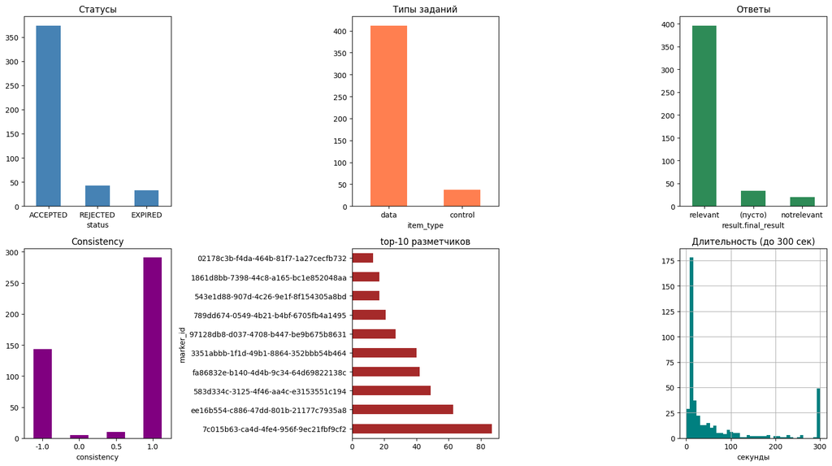

```python
fig, axes = plt.subplots(2, 3, figsize=(16, 9))

df['status'].value_counts().plot(kind='bar', ax=axes[0,0], title='Статусы', color='steelblue')
axes[0,0].tick_params(axis='x', rotation=0)

df['item_type'].value_counts().plot(kind='bar', ax=axes[0,1], title='Типы заданий', color='coral')
axes[0,1].tick_params(axis='x', rotation=0)

df['result.final_result'].fillna('(пусто)').value_counts().plot(kind='bar', ax=axes[0,2], title='Ответы', color='seagreen')
axes[0,2].tick_params(axis='x', rotation=0)

df['consistency'].fillna(-1).value_counts().sort_index().plot(kind='bar', ax=axes[1,0], title='Consistency', color='purple')
axes[1,0].tick_params(axis='x', rotation=0)

top10 = df.groupby('marker_id').size().sort_values(ascending=False).head(10)
top10.plot(kind='barh', ax=axes[1,1], title='top-10 разметчиков', color='brown')

df['duration_sec'].clip(upper=300).hist(bins=40, ax=axes[1,2], color='teal')
axes[1,2].set_title('Длительность (до 300 сек)')
axes[1,2].set_xlabel('секунды')

plt.tight_layout()
plt.savefig('analysis_charts.png', dpi=100, bbox_inches='tight')
plt.show()
```

## 10. Итоговые выводы

```python
print("ИТОГИ")
print(f"Всего заданий: {len(df)}")
print(f"Принято: {(df['status']=='ACCEPTED').sum()}")
print(f"Проблемных: {len(problem)} ({round(len(problem)/len(df)*100, 1)}%)")
print(f"relevant / notrelevant: {rel} / {notrel}")
print(f"Control провалено: {len(control_df)} из {len(control_df)}")
print(f"top-5 разметчиков: {top5_total} заданий ({round(top5_total/len(df)*100, 1)}%)")
print(f"Медиана времени: {df['duration_sec'].median():.1f} сек")
```

[output not shown]

## Итоговые выводы

## Данные анализа показывают проблему с дисциплиной разметчиков. 37 из 37 Control заданий провалено. При этом ручная сверка показывает, что в 27 Control заданиях разметчики ответили верно. Возможно, что система control_passed настроена некорректно или содержит техническую фичу, по которой засчитывается задание.

## Ручная сверка значений control_correct и result.final_result не масштабируемое решение, требующее постоянного анализа. Возможно стоит пересмотреть логику control_passed.